# Assignment 8: Visualization - Making a bar race

*How to do it?*:

- Open the Rmarkdown file of this assignment (link) in Rstudio.
- Right under each **question**, insert a code chunk (you can use the hotkey `Ctrl + Alt + I` to add a code chunk) and code the solution for the question.
- `Knit` the rmarkdown file (hotkey: `Ctrl + Alt + K`) to export an html.
- Publish the html file to your Githiub Page.

*Submission*: Submit the link on Github of the assignment to Canvas

1. Install two packages `gganimate` and `gifski` then restart Rstudio. Using the `Adult Census Income` data, make an animation using `geom_point` and `transition_states`.

```r
# Install Packages
install.packages("gganimate")
install.packages("gifski")
```

```r
library(gganimate)
library(gifski)
library(tidyverse)
df <- read_csv("https://bryantstats.github.io/math421/data/adult_census.csv")
str(df)
```

```
## spc_tbl_ [32,561 × 15] (S3: spec_tbl_df/tbl_df/tbl/data.frame)
##  $ age           : num [1:32561] 90 82 66 54 41 34 38 74 68 41 ...
##  $ workclass     : chr [1:32561] "?" "Private" "?" "Private" ...
##  $ fnlwgt        : num [1:32561] 77053 132870 186061 140359 264663 ...
##  $ education     : chr [1:32561] "HS-grad" "HS-grad" "Some-college" "7th-8th" ...
##  $ education.num : num [1:32561] 9 9 10 4 10 9 6 16 9 10 ...
##  $ marital.status: chr [1:32561] "Widowed" "Widowed" "Widowed" "Divorced" ...
##  $ occupation    : chr [1:32561] "?" "Exec-managerial" "?" "Machine-op-inspct" ...
##  $ relationship  : chr [1:32561] "Not-in-family" "Not-in-family" "Unmarried" "Unmarried" ...
##  $ race          : chr [1:32561] "White" "White" "Black" "White" ...
##  $ sex           : chr [1:32561] "Female" "Female" "Female" "Female" ...
##  $ capital.gain  : num [1:32561] 0 0 0 0 0 0 0 0 0 0 ...
##  $ capital.loss  : num [1:32561] 4356 4356 4356 3900 3900 ...
##  $ hours.per.week: num [1:32561] 40 18 40 40 40 45 40 20 40 60 ...
##  $ native.country: chr [1:32561] "United-States" "United-States" "United-States" "United-States" ...
##  $ income        : chr [1:32561] "<=50K" "<=50K" "<=50K" "<=50K" ...
##  - attr(*, "spec")=
##   .. cols(
##   ..   age = col_double(),
##   ..   workclass = col_character(),
##   ..   fnlwgt = col_double(),
##   ..   education = col_character(),
##   ..   education.num = col_double(),
##   ..   marital.status = col_character(),
##   ..   occupation = col_character(),
##   ..   relationship = col_character(),
##   ..   race = col_character(),
##   ..   sex = col_character(),
##   ..   capital.gain = col_double(),
##   ..   capital.loss = col_double(),
##   ..   hours.per.week = col_double(),
##   ..   native.country = col_character(),
##   ..   income = col_character()
##   .. )
##  - attr(*, "problems")=<externalptr>
```

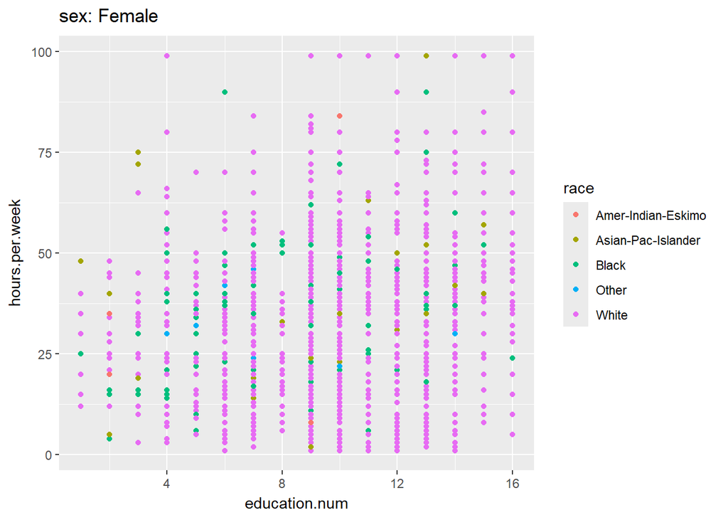

```r
df |> ggplot(aes(x = education.num, y = hours.per.week, color = race)) +
  geom_point() +
  transition_states(sex) +
  labs(title = 'sex: {closest_state}')
```

2. Using the `Adult Census Income` data, make an animation using `geom_bar` and `transition_states`.

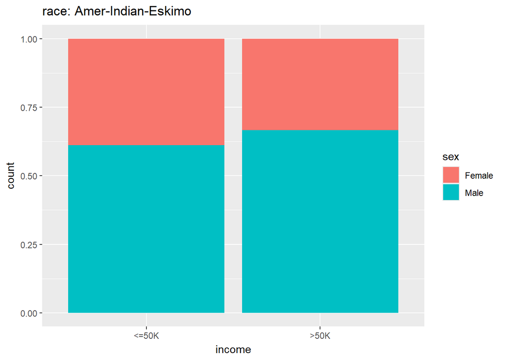

```r
df |> ggplot(aes(x = income, fill = sex)) +
  geom_bar(position = 'fill') +
  transition_states(race) +
  labs(title = 'race: {closest_state}')
```

3. Use the WHO’s dataset at [this link](https://covid19.who.int/WHO-COVID-19-global-data.csv). Make a top-10 bar race by months between countries on the number of deaths by Covid 19 in 2021.

```r
df1 <- read_csv("https://bryantstats.github.io/math421/data/WHO-COVID-19-global-data.csv")
str(df1)
```

```
## spc_tbl_ [232,023 × 8] (S3: spec_tbl_df/tbl_df/tbl/data.frame)
##  $ Date_reported    : Date[1:232023], format: "2020-01-03" "2020-01-04" ...
##  $ Country_code     : chr [1:232023] "AF" "AF" "AF" "AF" ...
##  $ Country          : chr [1:232023] "Afghanistan" "Afghanistan" "Afghanistan" "Afghanistan" ...
##  $ WHO_region       : chr [1:232023] "EMRO" "EMRO" "EMRO" "EMRO" ...
##  $ New_cases        : num [1:232023] 0 0 0 0 0 0 0 0 0 0 ...
##  $ Cumulative_cases : num [1:232023] 0 0 0 0 0 0 0 0 0 0 ...
##  $ New_deaths       : num [1:232023] 0 0 0 0 0 0 0 0 0 0 ...
##  $ Cumulative_deaths: num [1:232023] 0 0 0 0 0 0 0 0 0 0 ...
##  - attr(*, "spec")=
##   .. cols(
##   ..   Date_reported = col_date(format = ""),
##   ..   Country_code = col_character(),
##   ..   Country = col_character(),
##   ..   WHO_region = col_character(),
##   ..   New_cases = col_double(),
##   ..   Cumulative_cases = col_double(),
##   ..   New_deaths = col_double(),
##   ..   Cumulative_deaths = col_double()
##   .. )
##  - attr(*, "problems")=<externalptr>
```

```r
# Data
library(lubridate)
df1_data <- df1 |>
  filter(year(Date_reported) == 2021) |>
  group_by(month = month(Date_reported, label = TRUE, abbr = FALSE), Country) |>
  summarise(total_new_deaths = sum(New_deaths))

df1_data_2 <- df1_data |>
  group_by(month) |>
  mutate(rank=rank(-total_new_deaths))

df1_data_3 <- df1_data_2 |>  filter(rank <= 10)
```

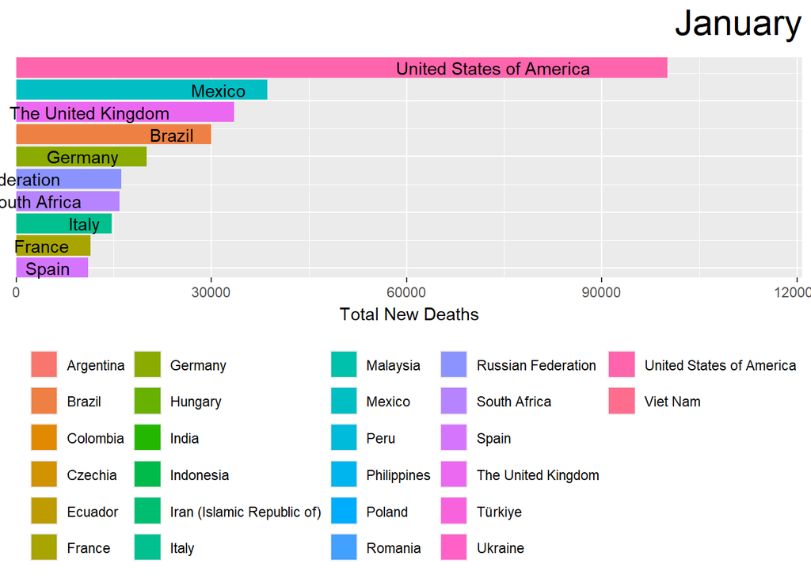

```r
# Bar race
p1 <- df1_data_3 |>
  ggplot(aes(x = rank, y = total_new_deaths, group = Country, fill = Country, label = Country)) +
  geom_col() +
  geom_text(aes(y = total_new_deaths,
                  label = Country),
              hjust = 1.4) +
    coord_flip(clip = "off",
               expand = FALSE)+
    scale_x_reverse()+
    labs(title='{closest_state}',
         y='Total New Deaths', x='', fill='')+
    theme(plot.title =
          element_text(hjust=1,size=22),
          axis.ticks.y=element_blank(),
          axis.text.y=element_blank(),
          legend.position = "bottom") +
    transition_states(month) +
    ease_aes("cubic-in-out")
animate(p1, nframes=400)
```

4. Make a bar race using a dataset of your own interest. You may use the dataset that we use in class (https://covidtracking.com/data/download/all-states-history.csv) but you should make a different bar racev from ones in the slides.

```r
df2 <- read_csv("https://bryantstats.github.io/math421/data/all-states-history.csv")
str(df2)
```

```
## spc_tbl_ [20,780 × 41] (S3: spec_tbl_df/tbl_df/tbl/data.frame)
##  $ date                            : Date[1:20780], format: "2021-03-07" "2021-03-07" ...
##  $ state                           : chr [1:20780] "AK" "AL" "AR" "AS" ...
##  $ death                           : num [1:20780] 305 10148 5319 0 16328 ...
##  $ deathConfirmed                  : num [1:20780] NA 7963 4308 NA 14403 ...
##  $ deathIncrease                   : num [1:20780] 0 -1 22 0 5 258 3 0 0 9 ...
##  $ deathProbable                   : num [1:20780] NA 2185 1011 NA 1925 ...
##  $ hospitalized                    : num [1:20780] 1293 45976 14926 NA 57907 ...
##  $ hospitalizedCumulative          : num [1:20780] 1293 45976 14926 NA 57907 ...
##  $ hospitalizedCurrently           : num [1:20780] 33 494 335 NA 963 ...
##  $ hospitalizedIncrease            : num [1:20780] 0 0 11 0 44 0 18 0 0 0 ...
##  $ inIcuCumulative                 : num [1:20780] NA 2676 NA NA NA ...
##  $ inIcuCurrently                  : num [1:20780] NA NA 141 NA 273 ...
##  $ negative                        : num [1:20780] NA 1931711 2480716 2140 3073010 ...
##  $ negativeIncrease                : num [1:20780] 0 2087 3267 0 13678 ...
##  $ negativeTestsAntibody           : num [1:20780] NA NA NA NA NA ...
##  $ negativeTestsPeopleAntibody     : logi [1:20780] NA NA NA NA NA NA ...
##  $ negativeTestsViral              : num [1:20780] 1660758 NA 2480716 NA NA ...
##  $ onVentilatorCumulative          : num [1:20780] NA 1515 1533 NA NA ...
##  $ onVentilatorCurrently           : num [1:20780] 2 NA 65 NA 143 NA NA NA 16 NA ...
##  $ positive                        : num [1:20780] 56886 499819 324818 0 826454 ...
##  $ positiveCasesViral              : num [1:20780] NA 392077 255726 0 769935 ...
##  $ positiveIncrease                : num [1:20780] 0 408 165 0 1335 ...
##  $ positiveScore                   : num [1:20780] 0 0 0 0 0 0 0 0 0 0 ...
##  $ positiveTestsAntibody           : num [1:20780] NA NA NA NA NA ...
##  $ positiveTestsAntigen            : num [1:20780] NA NA NA NA NA ...
##  $ positiveTestsPeopleAntibody     : logi [1:20780] NA NA NA NA NA NA ...
##  $ positiveTestsPeopleAntigen      : num [1:20780] NA NA 81803 NA NA ...
##  $ positiveTestsViral              : num [1:20780] 68693 NA NA NA NA ...
##  $ recovered                       : num [1:20780] NA 295690 315517 NA NA ...
##  $ totalTestEncountersViral        : num [1:20780] NA NA NA NA NA ...
##  $ totalTestEncountersViralIncrease: num [1:20780] 0 0 0 0 0 ...
##  $ totalTestResults                : num [1:20780] 1731628 2323788 2736442 2140 7908105 ...
##  $ totalTestResultsIncrease        : num [1:20780] 0 2347 3380 0 45110 ...
##  $ totalTestsAntibody              : num [1:20780] NA NA NA NA 580569 ...
##  $ totalTestsAntigen               : num [1:20780] NA NA NA NA NA ...
##  $ totalTestsPeopleAntibody        : num [1:20780] NA 119757 NA NA 444089 ...
##  $ totalTestsPeopleAntigen         : num [1:20780] NA NA 481311 NA NA ...
##  $ totalTestsPeopleViral           : num [1:20780] NA 2323788 NA NA 3842945 ...
##  $ totalTestsPeopleViralIncrease   : num [1:20780] 0 2347 0 0 14856 ...
```

[output cut: 32 more lines]

```
##   ..   recovered = col_double(),
##   ..   totalTestEncountersViral = col_double(),
##   ..   totalTestEncountersViralIncrease = col_double(),
##   ..   totalTestResults = col_double(),
##   ..   totalTestResultsIncrease = col_double(),
##   ..   totalTestsAntibody = col_double(),
##   ..   totalTestsAntigen = col_double(),
##   ..   totalTestsPeopleAntibody = col_double(),
##   ..   totalTestsPeopleAntigen = col_double(),
##   ..   totalTestsPeopleViral = col_double(),
##   ..   totalTestsPeopleViralIncrease = col_double(),
##   ..   totalTestsViral = col_double(),
##   ..   totalTestsViralIncrease = col_double()
##   .. )
##  - attr(*, "problems")=<externalptr>
```

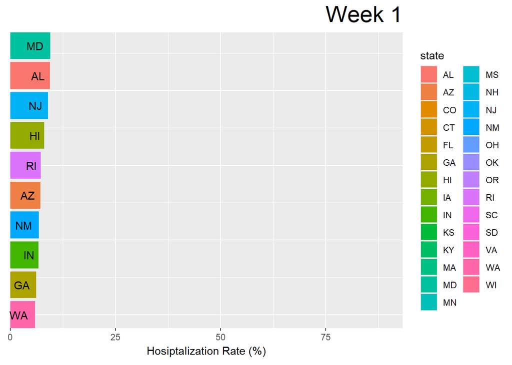

```r
# Data
df2_1 <- df2 |> filter(deathIncrease > 0, hospitalizedIncrease > 0, positiveIncrease > 0)

df2_2 <- df2_1 |> group_by(week = week(date), state) |> summarise(mean = mean((hospitalized/positive) * 100))
df2_3 <- df2_2|> group_by(week) |> mutate(rank = rank(-mean))
df2_4 <- df2_3 |> filter(rank <= 10)

# Bar race
plot <- df2_4 |>  ggplot(aes(x = rank, y = mean, group = state, fill = state, label = state)) + geom_col()+
    geom_text(aes(y = mean, label = state), hjust = 1.4)+
    coord_flip(clip = "off", expand = FALSE) +scale_x_reverse()+
    labs(title = 'Week {closest_state}', x = '', y = 'Hosiptalization Rate (%)', fill = 'state') +
    theme(plot.title = element_text(hjust = 1, size = 22),
          axis.ticks.y = element_blank(),
          axis.text.y  = element_blank()) +
    transition_states(week)+
    ease_aes("cubic-in-out")
animate(plot, nframes = 400)
```